# SLV Practical Week 6

Shannon Dickson

October 17 2022

```r
# Packages
library(MASS)
library(ISLR)
library(tidyverse)

library(pROC)

library(rpart)
library(rpart.plot)
library(randomForest)
```

```r
treat <- read_csv("cardiovascular_treatment.csv") %>%
  mutate(severity = as.factor(severity),
         gender   = as.factor(gender),
         dose     = as.factor(dose),
         response = as.factor(response))

set.seed(6369693)
```

# Confusion matrix

**1. Create a logistic regression model `lr_mod` for this data using the formula response `~ .` and create a confusion matrix based on a .5 cutoff probability.**

```r
# Logistic model
lr_mod <- glm(response ~., treat, family = "binomial")

# Predicted probabilities
probs1 <- predict(lr_mod, type = "response")

# Classification
preds1 <- ifelse(probs1 > 0.5, 1, 0)

# Confusion matrix
cm1 <- table(true = treat$response, pred = preds1)
```

**2. Calculate the accuracy, true positive rate (sensitivity), the true negative rate (specificity), the false positive rate, the positive predictive value, and the negative predictive value. You can use the confusion matrix table on wikipedia. What can you say about the model performance? Which metrics are most relevant if this model were to be used in the real world?**

**True Positive (TN)** - This is correctly classified as the class if interest / target. **True Negative (TN)** - This is correctly classified as not a class of interest / target. **False Positive (FP)** - This is wrongly classified as the class of interest / target. **False Negative (FN)** - This is wrongly classified as not a class of interest / target

```r
# Accuracy is .7, meaning that 30% of the patients are misclassified

# [TPR] If the patient will respond to treatment, there is an 77% probability
# that the model will detect this

# [TNR] If the patient will not respond to treatment, there is a 63% prob
# that the model will detect this

# [FPR] If the patient does not respond to treatment, there is a 37% chance
# he or she will anyway be predicted to respond to the treatment

# [PPV] If the patient is predicted to respond to the treatment, there is a
# 67% chance they will actually respond to the treatment

# [NPV] If the patient is predicted to not respond to the treatment, there is
# a 73% probability that they will indeed not respond to the treatment

# The last two metrics are very relevant: if a new patient comes in you will
# only know the prediction and not the true value
```

```r
# Metrics of the confusion matrix
TP <- cm1[2, 2]
TN <- cm1[1, 1]
FP <- cm1[1, 2]
FN <- cm1[2, 1]

# Bind to a tibble
tibble(
  ACC = (TP + TN) / sum(cm1),
  TPR = TP / (TP + FN),
  TNR = TN / (TN + FP),
  FPR = FP / (TN + FP),
  PPV = TP / (TP + FP),
  NPV = TN / (TN + FN))
```

```
## # A tibble: 1 × 6
##     ACC   TPR   TNR   FPR   PPV   NPV
##   <dbl> <dbl> <dbl> <dbl> <dbl> <dbl>
## 1 0.700 0.770 0.630 0.370 0.674 0.734
```

**3. Create an LDA model lda_mod for the same prediction problem. Compare its performance to the LR model.**

```r
# LDA model
lda_mod <- lda(response ~., treat)

# Predicted classes
pred2 <- predict(lda_mod)$class

# Confusion matrix
cm2 <- table(true = treat$response, pred = pred2)

# Metrics of the confusion matrix
TN <- cm2[1, 1]
TP <- cm2[2, 2]
FN <- cm2[2, 1]
FP <- cm2[1, 2]

# PPV
TP / (TP + FP)
```

```
## [1] 0.6736111
```

```r
# NPV
TN / (TN + FN)
```

```
## [1] 0.733945
```

**4. Compare the classification performance of lr_mod and lda_mod for the new patients in the data/new_patients.csv.**

```r
# Read new data
new_patients <- read_csv("new_patients.csv") %>%
  mutate(severity = as.factor(severity),
         gender   = as.factor(gender),
         dose     = as.factor(dose),
         response = as.factor(response))
```

```r
preds_lda_test <- predict(lda_mod, newdata = new_patients)$class

probs_lr_test <- predict(lr_mod, newdata = new_patients, type = "response")

preds_lr_test <- ifelse(probs_lr_test > .5, 1, 0)
```

```r
# Confusion matrix for LDA
cm_lda_test <- table(true = new_patients$response, pred = preds_lda_test)

# Confusion matrix for logistic regression
cm_lr_test <- table(true = new_patients$response, pred = preds_lr_test )

cm_lda_test
```

```
##     pred
## true  0  1
##    0 16 11
##    1  9 14
```

```r
cm_lr_test
```

```
##     pred
## true  0  1
##    0 16 11
##    1  9 14
```

```r
# they perform the same
```

```r
# NPV
PPV <- cm_lda_test[2, 2] / sum(cm_lda_test[, 2])
# PPV
NPV <- cm_lda_test[1, 1] / sum(cm_lda_test[, 1])

PPV
```

```
## [1] 0.56
```

```r
NPV
```

```
## [1] 0.64
```

```r
# PPV and NPV for the test data are worse - just above chance level
```

# Brier score

**Calculate the out-of-sample brier score for the lr_mod and give an interpretation of this number.**

```r
# BS / MSE = 0.23
mean((probs_lr_test - (as.numeric(new_patients$response) - 1)) ^ 2)
```

```
## [1] 0.2283307
```

# ROC curve

**5. Create two LR models: lr1_mod with severity, age, and bb_score as predictors, and lr2_mod with the formula response ~ age + I(age^2) + gender + bb_score * prior_cvd * dose. Save the predicted probabilities on the training data.**

- **AUC**, smoothness depends on number of observations, but also how many models with different decision thresholds.

```r
# Logistic regression model 1 and predicted probabilities
lr1_mod <- glm(response ~ severity + bb_score + age, family = "binomial", data = treat)

prob_lr1 <- predict(lr1_mod, type = "response")

# Logistic regression model 2 and predicted probabilities
lr2_mod <- glm(response ~ age + I(age^2) + gender + bb_score * prior_cvd * dose, family = "binomial", data = treat)

prob_lr2 <- predict(lr2_mod, type = "response")
```

**6. Use the function roc() from the pROC package to create two ROC objects with the predicted probabilities: roc_lr1 and roc_lr2. Use the ggroc() method on these objects to create an ROC curve plot for each. Which model performs better? Why?**

```r
roc_lr1 <- roc(treat$response, prob_lr1)
```

```r
roc_lr2 <- roc(treat$response, prob_lr2)
```

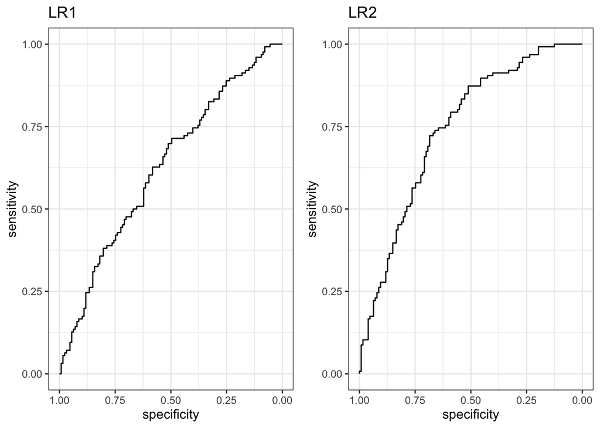

```r
# Plot for model 1
p1<-  ggroc(roc_lr1) +
       labs(title = "LR1") +
       theme_bw()

# Plot for model 2
p2 <- ggroc(roc_lr2) +
       labs(title = "LR2") +
       theme_bw()

library(ggpubr)
# Both
ggarrange(p1, p2)
```

**7. Print the roc_lr1 and roc_lr2 objects. Which AUC value is higher? How does this relate to the plots you made before? What is the minimum AUC value and what would a “perfect” AUC value be and how would it look in a plot?**

```r
# AUC
# - higher for model 2 (min 0.5 max 1)
# - the AUC for a perfect model would be everything under 1
roc_lr1
```

```
##
## Call:
## roc.default(response = treat$response, predictor = prob_lr1)
##
## Data: prob_lr1 in 127 controls (treat$response 0) < 126 cases (treat$response 1).
## Area under the curve: 0.6253
```

```r
roc_lr2
```

```
##
## Call:
## roc.default(response = treat$response, predictor = prob_lr2)
##
## Data: prob_lr2 in 127 controls (treat$response 0) < 126 cases (treat$response 1).
## Area under the curve: 0.7405
```

```r
# - AUC is the probability that the classifier ranks the person who responds to treatment higher, given one pps who responds and one who doesn't
```

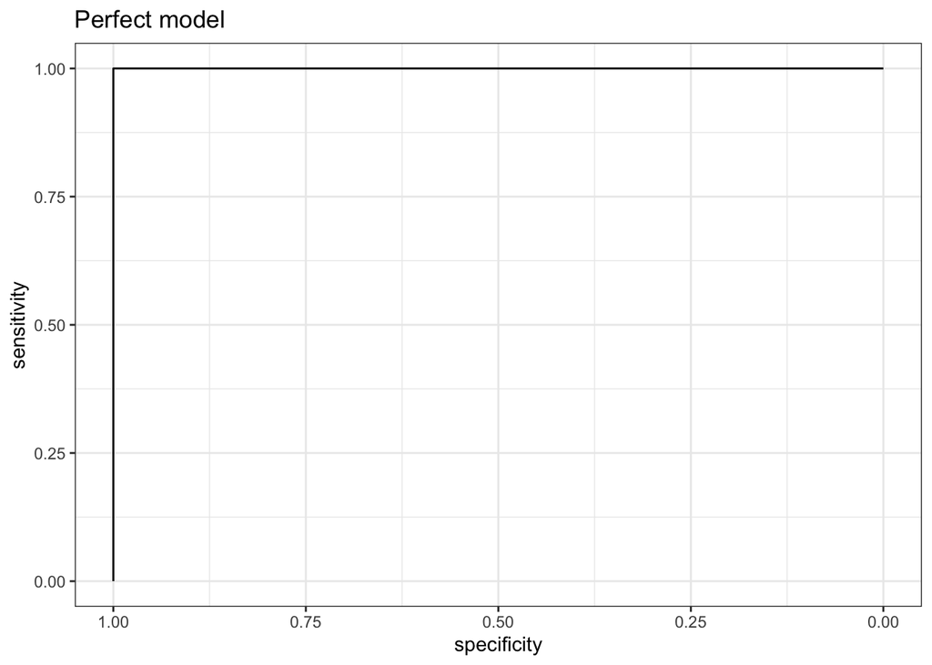

```r
ggplot(data.frame(x = c(1, 1, 0), y = c(0, 1, 1)),
       aes(x = x, y = y)) +
  geom_line() +
  xlim(1, 0) +
  labs(y = "sensitivity",
       x = "specificity",
       title = "Perfect model") +
  theme_bw()
```

# Iris dataset

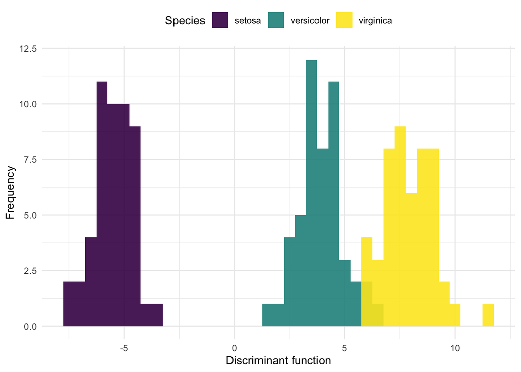

```r
# fit lda model, i.e. calculate model parameters
lda_iris <- lda(Species ~ ., data = iris)

# use those parameters to compute the first linear discriminant
first_ld <- -c(as.matrix(iris[, -5]) %*% lda_iris$scaling[,1])

# plot
tibble(
  ld = first_ld,
  Species = iris$Species
) %>%
  ggplot(aes(x = ld, fill = Species)) +
  geom_histogram(binwidth = .5, position = "identity", alpha = .9) +
  scale_fill_viridis_d(guide = ) +
  theme_minimal() +
  labs(
    x = "Discriminant function",
    y = "Frequency",
    main = "Fisher's linear discriminant function on Iris species"
  ) +
  theme(legend.position = "top")
```

**8. Explore the iris dataset using summaries and plots.**

```r
# Overview of the data
head(iris)
```

```
##   Sepal.Length Sepal.Width Petal.Length Petal.Width Species
## 1          5.1         3.5          1.4         0.2  setosa
## 2          4.9         3.0          1.4         0.2  setosa
## 3          4.7         3.2          1.3         0.2  setosa
## 4          4.6         3.1          1.5         0.2  setosa
## 5          5.0         3.6          1.4         0.2  setosa
## 6          5.4         3.9          1.7         0.4  setosa
```

```r
summary(iris)
```

```
##   Sepal.Length    Sepal.Width     Petal.Length    Petal.Width
##  Min.   :4.300   Min.   :2.000   Min.   :1.000   Min.   :0.100
##  1st Qu.:5.100   1st Qu.:2.800   1st Qu.:1.600   1st Qu.:0.300
##  Median :5.800   Median :3.000   Median :4.350   Median :1.300
##  Mean   :5.843   Mean   :3.057   Mean   :3.758   Mean   :1.199
##  3rd Qu.:6.400   3rd Qu.:3.300   3rd Qu.:5.100   3rd Qu.:1.800
##  Max.   :7.900   Max.   :4.400   Max.   :6.900   Max.   :2.500
##        Species
##  setosa    :50
##  versicolor:50
##  virginica :50
##
##
##
```

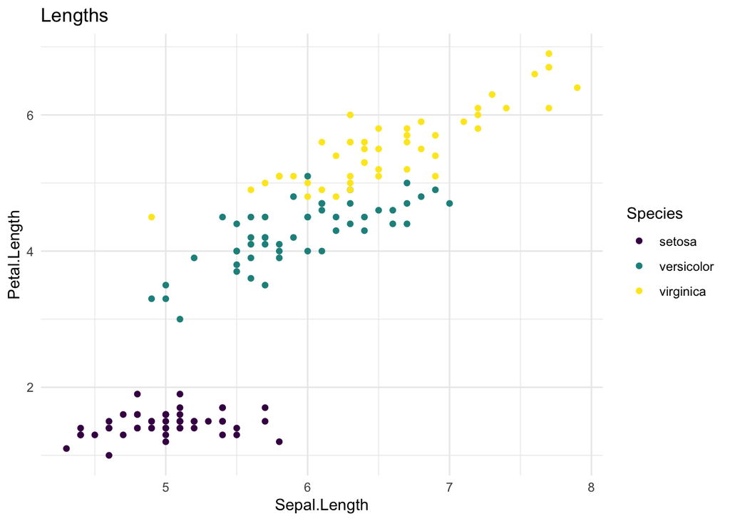

```r
# Some plots
iris %>%
  ggplot(aes(x = Sepal.Length, y = Petal.Length, colour = Species)) +
  geom_point() +
  labs(title = "Lengths",) +
  scale_colour_viridis_d() +
  theme_minimal()
```

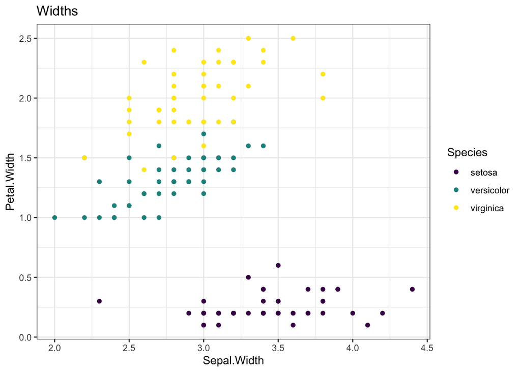

```r
iris %>%
  ggplot(aes(x = Sepal.Width, y = Petal.Width, colour = Species)) +
  geom_point() +
  labs(title = "Widths") +
  scale_colour_viridis_d() +
  theme_bw()
```

**9. Fit an additional LDA model, but this time with only `Sepal.Length` and `Sepal.Width` as predictors. Call this model `lda_iris_sepal`.**

```r
lda_iris_sepal <- lda(Species ~ Sepal.Length + Sepal.Width, data = iris)
```

**10.Create a confusion matrix of the `lda_iris` and `lda_iris_sepal` models. (NB: we did not split the dataset into training and test set, so use the training dataset to generate the predictions.). Which performs better in terms of accuracy?**

```r
# Confusion matrix for LDA with iris
table(true = iris$Species, predicted = predict(lda_iris)$class)
```

```
##             predicted
## true         setosa versicolor virginica
##   setosa         50          0         0
##   versicolor      0         48         2
##   virginica       0          1        49
```

```r
# Confusion matrix for LDA with sepal
table(true = iris$Species, predicted = predict(lda_iris_sepal)$class)
```

```
##             predicted
## true         setosa versicolor virginica
##   setosa         49          1         0
##   versicolor      0         36        14
##   virginica       0         15        35
```